# MQII - Monitoria 3

Sinara

2024-03-19

1. Introdução

Na última monitoria, exploramos a execução de uma regressão linear e a visualização dos resultados da projeção. No modelo Y = Xbeta + e, onde Y e X são variáveis aleatórias e (Yi, Xi) representam as observações para ( i = 1, 2, … n), assumimos uma distribuição normal para (Yi, Xi). O beta calculado (estimador amostral) é conhecido como Mínimos Quadrados Ordinários (MQO ou OLS).

2. Organizar dados

2.1. Abrir xlsx

Os dados são da Pesquisa da População Atual (Current Population Survey - CPS), que é uma pesquisa mensal de aproximadamente 57.000 domicílios nos Estados Unidos.

```r
library(readxl)
dados <- read_excel("dados_trab.xlsx")
```

2.2. Filtrar homens & brancos

```r
dados_filtrados <- subset(dados, dados[,11] == 1 & dados[,2] == 0)
```

2.3. Criar variáveis para a regressão

```r
dados_filtrados$lnwage <- log(dados_filtrados[,5]/(dados_filtrados[,6]*dados_filtrados[,7])) #log do salário/hora (salário anual * semanas trabalhadas por ano)/horas trabalhadas por mês)
dados_filtrados[,13] <- dados_filtrados$lnwage #arrumando o nome da variável

dados_filtrados$experience <- dados_filtrados[, 1] - dados_filtrados[, 4] - 6 # proxy da experiência
dados_filtrados[,14] <- dados_filtrados$experience #arrumando o nome da variável
```

2.4. Objetos para a regressão

```r
Y <- dados_filtrados$lnwage
X1 <- dados_filtrados$education
X2 <- dados_filtrados$experience
```

3. Estatísticas da amostra (serão utilizadas para estimar os Betas)

```r
# Tamanho da amostra
n <- length(Y)

# Médias das variáveis
media_Y <- mean(Y)
media_X1 <- mean(X1)
media_X2 <- mean(X2)
```

4. Coeficientes para um regressor (k = 1) - Regressão linear simples

```r
# Desvios em relação à média
desv_X1 <- X1 - media_X1
desv_Y <- Y - media_Y

# Covariância entre X1 e Y
soma_produtos_cruzados <- sum(desv_X1 * desv_Y)
covariancia_X1Y <- soma_produtos_cruzados / (n - 1)

# Variância de X1
soma_quadrados_desvios_X1 <- sum(desv_X1^2) #soma dos quadrados dos desvios
variancia_X1 <- soma_quadrados_desvios_X1 / (n - 1)

# Calcular os coeficientes beta0 e beta1 estimado
beta1 <- covariancia_X1Y / variancia_X1
beta0 <- media_Y - beta1 * media_X1

#Resultados
print(beta0)
```

```
## [1] 1.524485
```

```r
print(beta1)
```

```
## [1] 0.1117149
```

Que é o mesmo que:

```r
modelo1 <- lm(Y ~ X1)
summary(modelo1)
```

```
##
## Call:
## lm(formula = Y ~ X1)
##
## Residuals:
##      Min       1Q   Median       3Q      Max
## -11.1752  -0.3364   0.0162   0.3535   2.4952
##
## Coefficients:
##             Estimate Std. Error t value Pr(>|t|)
## (Intercept) 1.524485   0.019883   76.67   <2e-16 ***
## X1          0.111715   0.001411   79.15   <2e-16 ***
## ---
## Signif. codes:  0 '***' 0.001 '**' 0.01 '*' 0.05 '.' 0.1 ' ' 1
##
## Residual standard error: 0.627 on 24342 degrees of freedom
## Multiple R-squared:  0.2047, Adjusted R-squared:  0.2047
## F-statistic:  6265 on 1 and 24342 DF,  p-value: < 2.2e-16
```

OBS: beta1 é a inclinação da reta (ΔY/ΔX) e beta0 é a interseção da reta com o eixo y.

5. Coeficientes para mais de um regressor (k > 1) - Regressão linear múltipla

```r
# Somas
soma_X1 <- sum(X1)
soma_X2 <- sum(X2)
soma_Y <- sum(Y)

# Somas dos produtos
soma_X1Y <- sum(X1 * Y)
soma_X2Y <- sum(X2 * Y)
soma_X1X2 <- sum(X1 * X2)

# Produto das somas dividido por n
prod_s_X1Y <- (soma_X1 * soma_Y)/n
prod_s_X2Y <- (soma_X2 * soma_Y)/n
prod_s_X1X2 <- (soma_X1 * soma_X2)/n

# Covariância
cov_X1Y <- soma_X1Y - prod_s_X1Y
cov_X2Y <- soma_X2Y - prod_s_X2Y
cov_X1X2 <- soma_X1X2 - prod_s_X1X2

# Somas dos quadrados
soma_X1_sq <- sum(X1^2)
soma_X2_sq <- sum(X2^2)

# Quadrado das somas dividido por n
sq_soma_X1 <- (soma_X1^2)/n
sq_soma_X2 <- (soma_X2^2)/n

# Soma dos quadrados - quadrados das somas divido por n
sqt_X1 <- soma_X1_sq - sq_soma_X1
sqt_X2 <- soma_X2_sq - sq_soma_X2

# Calculando os coeficientes de regressão estimados para X1 e X2
beta1 <- (sqt_X2 * cov_X1Y - cov_X1X2 * cov_X2Y)/(sqt_X1 * sqt_X2 - (cov_X1X2)^2)
beta2 <- (sqt_X1 * cov_X2Y - cov_X1X2 * cov_X1Y)/(sqt_X1 * sqt_X2 - (cov_X1X2)^2)
beta0 <- media_Y -  beta1 * media_X1 - beta2 * media_X2

# Resultados
print(beta0)
```

```
## [1] 1.200944
```

```r
print(beta1)
```

```
## [1] 0.1177039
```

```r
print(beta2)
```

```
## [1] 0.01079205
```

Que é o mesmo que:

```r
modelo2 <- lm(Y ~ X1 + X2)
summary(modelo2)
```

```
##
## Call:
## lm(formula = Y ~ X1 + X2)
##
## Residuals:
##      Min       1Q   Median       3Q      Max
## -11.4223  -0.3112   0.0153   0.3422   2.5812
##
## Coefficients:
##              Estimate Std. Error t value Pr(>|t|)
## (Intercept) 1.2009443  0.0220780   54.40   <2e-16 ***
## X1          0.1177039  0.0013972   84.24   <2e-16 ***
## X2          0.0107921  0.0003456   31.23   <2e-16 ***
## ---
## Signif. codes:  0 '***' 0.001 '**' 0.01 '*' 0.05 '.' 0.1 ' ' 1
##
## Residual standard error: 0.6149 on 24341 degrees of freedom
## Multiple R-squared:  0.2353, Adjusted R-squared:  0.2353
## F-statistic:  3746 on 2 and 24341 DF,  p-value: < 2.2e-16
```

6. Resíduos dos Mínimos Quadrados

6.1. Média amostral dos resíduos igual a zero

```r
residuos <- residuals(modelo2) # Resíduos do modelo
mean(residuos) # Média dos resíduos
```

```
## [1] -3.530941e-17
```

A condição de os resíduos terem média igual a zero é uma propriedade desejável para um modelo de regressão linear, mas não é uma regra rígida. Muitas vezes é assumida ao interpretar os resultados da regressão.

6.2. Homocedasticidade

Em modelos lineares, temos o pressuposto de que a variabilidade dos erros é constante em todos os níveis das variáveis independentes. Como observar isso?

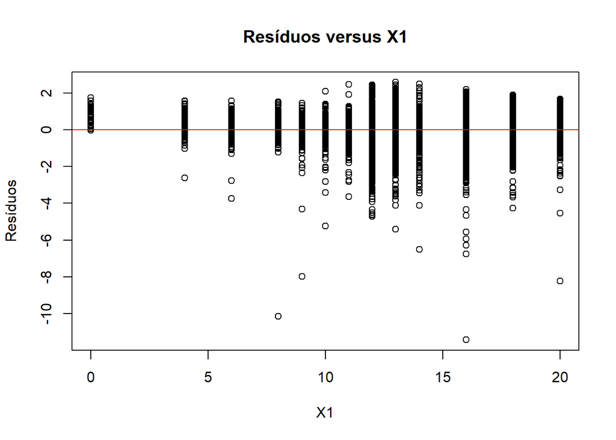

```r
# Plotar resíduos versus X1
plot(X1, residuos,
     main = "Resíduos versus X1",
     xlab = "X1",
     ylab = "Resíduos")
abline(h = 0, col = "red") # Linha horizontal em y = 0 para referência
```

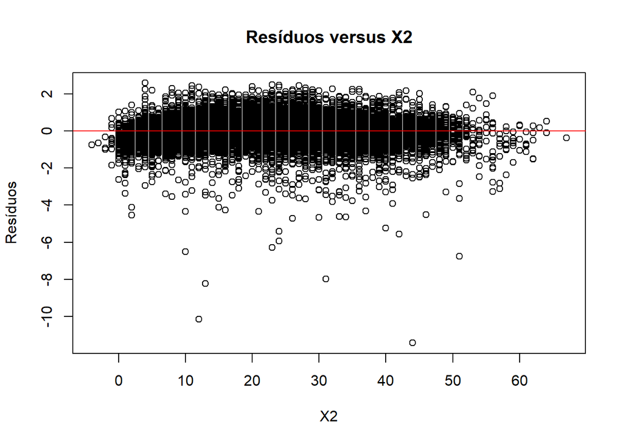

```r
# Plotar resíduos versus X2
plot(X2, residuos,
     main = "Resíduos versus X2",
     xlab = "X2",
     ylab = "Resíduos")
abline(h = 0, col = "red") # Linha horizontal em y = 0 para referência
```

Quando há homocedasticidade, os pontos de resíduos devem estar distribuídos aleatoriamente ao redor da linha horizontal em y = 0 (representando a ausência de padrão na variância dos resíduos).

6.3. Não autocorrelação dos resíduos

Se os resíduos exibirem autocorrelação significativa, as estimativas dos coeficientes de regressão podem ser imprecisas. Se houver autocorrelação nos resíduos, podemos observar padrões sistemáticos nos resíduos ao longo do tempo.

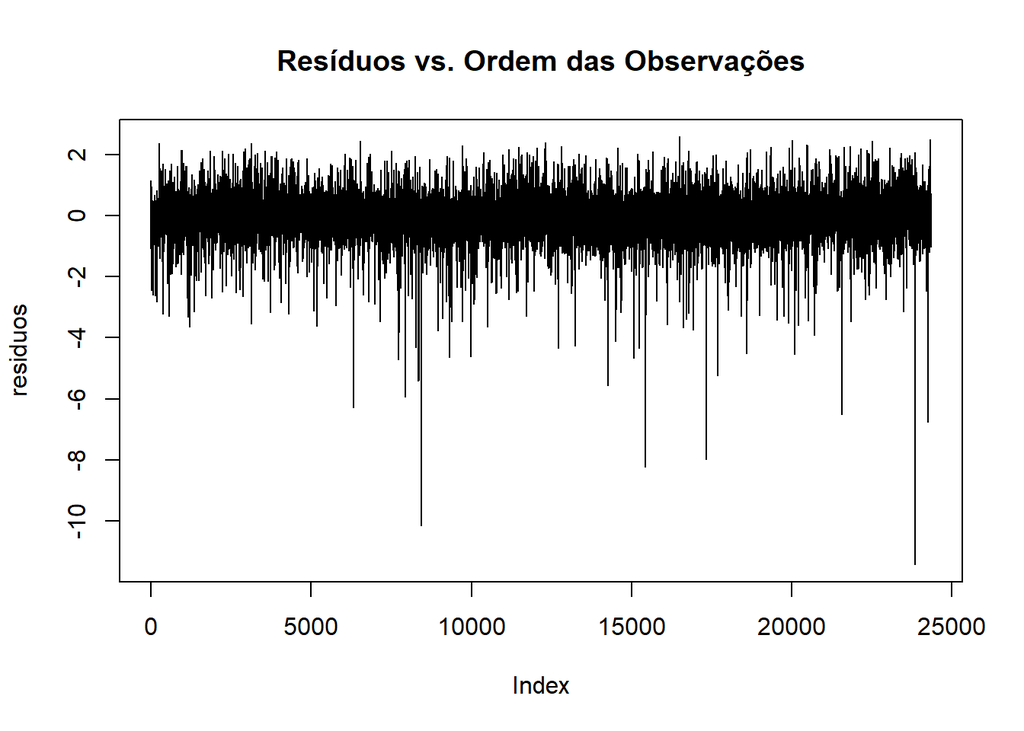

```r
plot(residuos, type = "l", main = "Resíduos vs. Ordem das Observações")
```

Se os resíduos parecerem aleatórios, sem nenhuma estrutura discernível, isso sugere que não há autocorrelação nos resíduos.

7. Coeficiente de determinação ou R-quadrado

Representa a fração da variabilidade da variável dependente que é explicada pelos regressores incluídos no modelo de regressão. Seus valores variam entre 0 e 1, onde 0 indica que o modelo não consegue explicar nenhuma variação nos dados, enquanto 1 indica que o modelo é capaz de explicar toda a variação dos dados.

```r
# Soma dos quadrados dos resíduos
sqres <- sum(residuos^2)

# Soma dos quadrados dos desvios de Y em relação à média
stq <- sum((Y - media_Y)^2)

# R-quadrado
1 - (sqres / stq)
```

```
## [1] 0.2353354
```

8. Frish-Waugh-Lowel (FWL)

FWL é usada para decompor os efeitos de variáveis independentes em um modelo de regressão linear múltipla, permitindo isolar o efeito de uma variável de interesse, controlando para outras variáveis independentes.

```r
# Residualizar as variáveis dependentes e independentes
residuos_Y <- residuals(lm(Y ~ X1 + X2))
residuos_X1 <- residuals(lm(X1 ~ X2))
residuos_X2 <- residuals(lm(X2 ~ X1))

# Reestimar o modelo com os resíduos como variáveis dependentes
modelo_FWL_Y <- lm(residuos_Y ~ residuos_X1 + residuos_X2)
summary(modelo_FWL_Y)
```

```
##
## Call:
## lm(formula = residuos_Y ~ residuos_X1 + residuos_X2)
##
## Residuals:
##      Min       1Q   Median       3Q      Max
## -11.4223  -0.3112   0.0153   0.3422   2.5812
##
## Coefficients:
##               Estimate Std. Error t value Pr(>|t|)
## (Intercept)  6.831e-17  3.941e-03       0        1
## residuos_X1  1.649e-16  1.411e-03       0        1
## residuos_X2 -5.795e-18  3.489e-04       0        1
##
## Residual standard error: 0.6149 on 24341 degrees of freedom
## Multiple R-squared:  5.744e-31,  Adjusted R-squared:  -8.217e-05
## F-statistic: 6.99e-27 on 2 and 24341 DF,  p-value: 1
```

Os coeficientes estimados para as variáveis independentes residuais indicam a relação entre esses resíduos e a variável dependente residual. Um coeficiente positivo indica que um aumento nos resíduos da variável independente está associado a um aumento nos resíduos da variável dependente, e vice-versa.